# Intro to R

Day 4

Class date: 02/07/2017 Last update: 02/07/17

# 1 ggplot2

## 1.1 Info

- R package for making elegant plots quickly
- Written by Hadley Wickham when he was a graduate student at Iowa State
- Automatcally deals with spacings, text, titles but also allows you to annotate by “adding”
- Superficial similarity to lattice but generally easier/more intuitive
- Plots are built up in layers – Plot the data, overlay a summary, metadata and annotation
- Works with a data frame

## 1.2 Components

- aestheic mappings: how data are mapped to color, size
- facets: for conditional plots
- geoms: geometric objects like points, lines, shapes
- stats: statitcal transformations
- scales: what scale an aesthetic map uses (example: male = red, female = blue)
- coordinate system

The basic structure is as follows…

```r
ggplot(dataframe, aes(x = , y = )) +
```

Aesthetics can include `x`, `y`, `shape`, `color`, `fill`, and others.

You then add geoms (`geom_point()`, `geom_smooth()`, `geom_boxplot()`, among others).

```r
library(tidyverse)
```

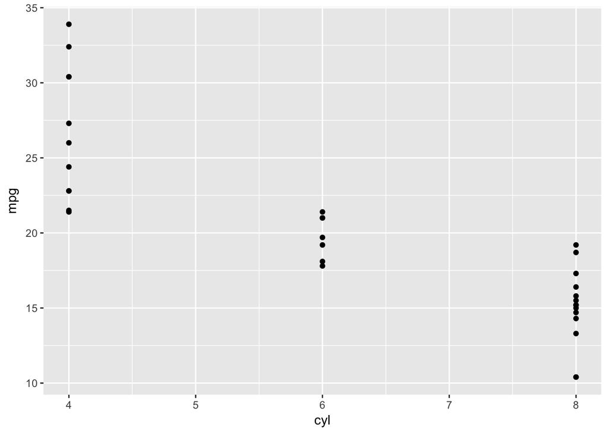

```r
ggplot(mtcars, aes(x = cyl, y = mpg)) +
  geom_point()
```

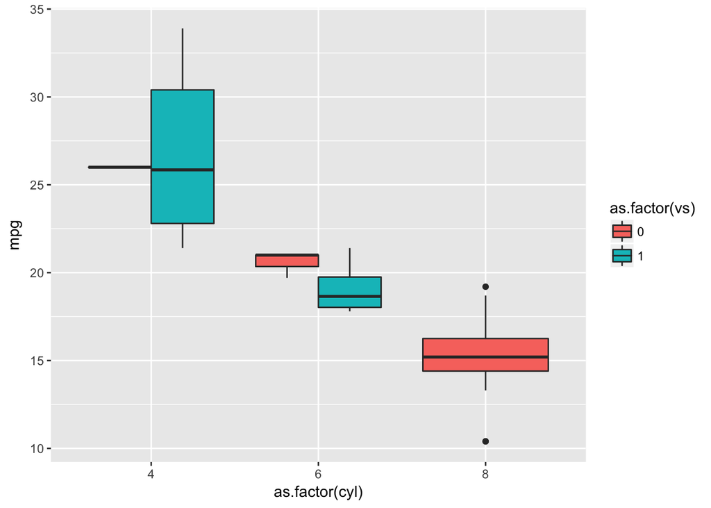

```r
ggplot(mtcars, aes(x = as.factor(cyl), y = mpg, fill = as.factor(vs))) +
  geom_boxplot()
```

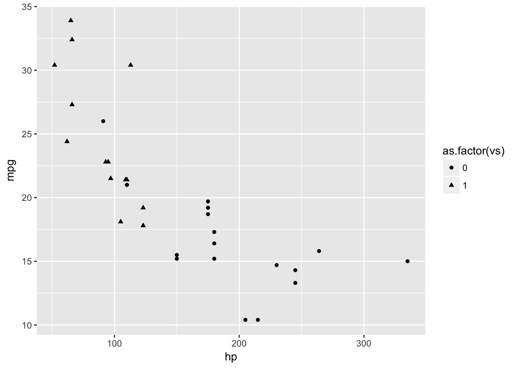

```r
ggplot(mtcars, aes(x = hp, y = mpg, shape = as.factor(vs))) +
  geom_point()
```

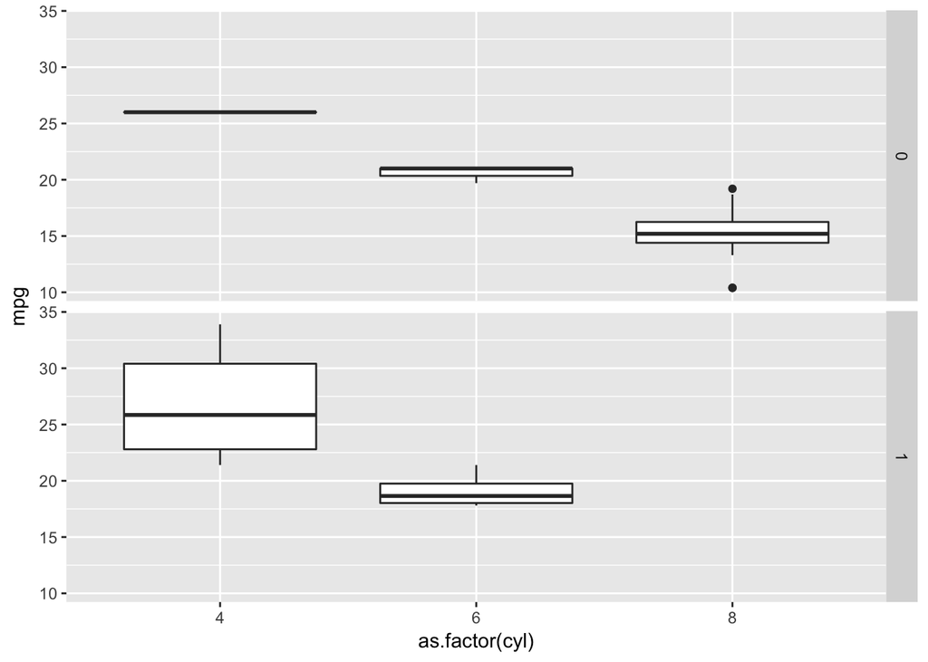

```r
ggplot(mtcars, aes(x = as.factor(cyl), y = mpg)) +
  geom_boxplot() +
  facet_grid(as.factor(vs) ~ .)
```

# 2 Download data from the internet

We can download a file from the internet directly in R.

```r
# Optionally assign the url to an object
fileUrl <- 'https://dl.dropboxusercontent.com/u/7256527/data.csv'

# Download file
download.file(fileUrl, destfile = "./data.csv", method = "curl")
```

# 3 Data reformatting

## 3.1 Wide to long

```r
set.seed(1)
wide <- data.frame(
  participant = c("p1", "p2", "p3", "p4", "p5", "p6"),
  info = c("g1m", "g1m", "g1f", "g2m", "g2m", "g2m"),
  day1score = rnorm(n = 6, mean = 80, sd = 15),
  day2score = rnorm(n = 6, mean = 88, sd = 8)
)

print(wide)
```

```
##   participant info day1score day2score
## 1          p1  g1m  70.60319  91.89943
## 2          p2  g1m  82.75465  93.90660
## 3          p3  g1f  67.46557  92.60625
## 4          p4  g2m 103.92921  85.55689
## 5          p5  g2m  84.94262 100.09425
## 6          p6  g2m  67.69297  91.11875
```

As you can see, this data set is in wide format. In order to do most analyses, we want **tidy data**. That is, each column should represent a variable and each row should represent an observation. A simple way to reformat the data is with the `gather()` function from the `tidyr` package. The basic format is as follows:

```r
gather(df, key = groupingVar, val = dv)
```

```r
library(tidyr)

df_long <- gather(data = wide, key = day, val = score, -participant, -info)
print(df_long)
```

```
##    participant info       day     score
## 1           p1  g1m day1score  70.60319
## 2           p2  g1m day1score  82.75465
## 3           p3  g1f day1score  67.46557
## 4           p4  g2m day1score 103.92921
## 5           p5  g2m day1score  84.94262
## 6           p6  g2m day1score  67.69297
## 7           p1  g1m day2score  91.89943
## 8           p2  g1m day2score  93.90660
## 9           p3  g1f day2score  92.60625
## 10          p4  g2m day2score  85.55689
## 11          p5  g2m day2score 100.09425
## 12          p6  g2m day2score  91.11875
```

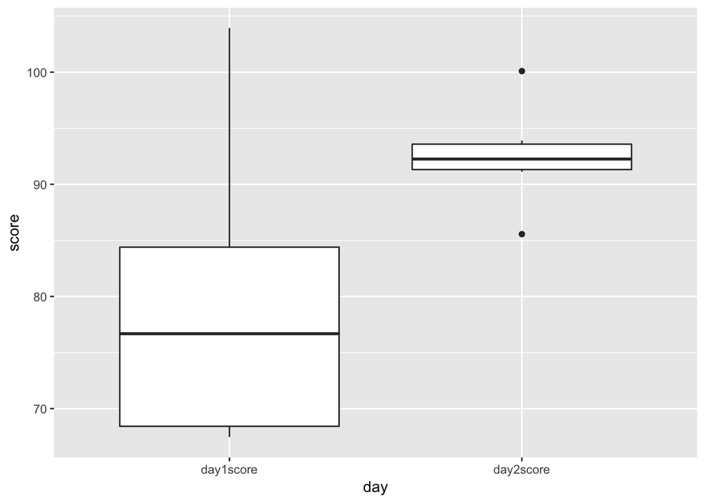

```r
ggplot(df_long, aes(x = day, y = score)) +
  geom_boxplot()
```

## 3.2 More subsetting with logical statements

- `==`: equal
- `!=`: not equal
- `>`: greater than
- `<`: less than
- `>=`: greater than or equal to
- `<=`: less than or equal to
- `|`: or
- `&`: and

```r
# All rows in which `cyl` does not equal 6
mtcars[mtcars$cyl != 6, ]
```

```
##                      mpg cyl  disp  hp drat    wt  qsec vs am gear carb
## Datsun 710          22.8   4 108.0  93 3.85 2.320 18.61  1  1    4    1
## Hornet Sportabout   18.7   8 360.0 175 3.15 3.440 17.02  0  0    3    2
## Duster 360          14.3   8 360.0 245 3.21 3.570 15.84  0  0    3    4
## Merc 240D           24.4   4 146.7  62 3.69 3.190 20.00  1  0    4    2
## Merc 230            22.8   4 140.8  95 3.92 3.150 22.90  1  0    4    2
## Merc 450SE          16.4   8 275.8 180 3.07 4.070 17.40  0  0    3    3
## Merc 450SL          17.3   8 275.8 180 3.07 3.730 17.60  0  0    3    3
## Merc 450SLC         15.2   8 275.8 180 3.07 3.780 18.00  0  0    3    3
## Cadillac Fleetwood  10.4   8 472.0 205 2.93 5.250 17.98  0  0    3    4
## Lincoln Continental 10.4   8 460.0 215 3.00 5.424 17.82  0  0    3    4
## Chrysler Imperial   14.7   8 440.0 230 3.23 5.345 17.42  0  0    3    4
## Fiat 128            32.4   4  78.7  66 4.08 2.200 19.47  1  1    4    1
## Honda Civic         30.4   4  75.7  52 4.93 1.615 18.52  1  1    4    2
## Toyota Corolla      33.9   4  71.1  65 4.22 1.835 19.90  1  1    4    1
## Toyota Corona       21.5   4 120.1  97 3.70 2.465 20.01  1  0    3    1
## Dodge Challenger    15.5   8 318.0 150 2.76 3.520 16.87  0  0    3    2
## AMC Javelin         15.2   8 304.0 150 3.15 3.435 17.30  0  0    3    2
## Camaro Z28          13.3   8 350.0 245 3.73 3.840 15.41  0  0    3    4
## Pontiac Firebird    19.2   8 400.0 175 3.08 3.845 17.05  0  0    3    2
## Fiat X1-9           27.3   4  79.0  66 4.08 1.935 18.90  1  1    4    1
## Porsche 914-2       26.0   4 120.3  91 4.43 2.140 16.70  0  1    5    2
## Lotus Europa        30.4   4  95.1 113 3.77 1.513 16.90  1  1    5    2
## Ford Pantera L      15.8   8 351.0 264 4.22 3.170 14.50  0  1    5    4
## Maserati Bora       15.0   8 301.0 335 3.54 3.570 14.60  0  1    5    8
## Volvo 142E          21.4   4 121.0 109 4.11 2.780 18.60  1  1    4    2
```

## 3.3 Add new variables

```r
mtcars$size <- NA
mtcars[mtcars$cyl == 8, 'size'] <- 'big'
mtcars[mtcars$cyl != 8, 'size'] <- 'small'
print(mtcars)
```

```
##                      mpg cyl  disp  hp drat    wt  qsec vs am gear carb
## Mazda RX4           21.0   6 160.0 110 3.90 2.620 16.46  0  1    4    4
## Mazda RX4 Wag       21.0   6 160.0 110 3.90 2.875 17.02  0  1    4    4
## Datsun 710          22.8   4 108.0  93 3.85 2.320 18.61  1  1    4    1
## Hornet 4 Drive      21.4   6 258.0 110 3.08 3.215 19.44  1  0    3    1
## Hornet Sportabout   18.7   8 360.0 175 3.15 3.440 17.02  0  0    3    2
## Valiant             18.1   6 225.0 105 2.76 3.460 20.22  1  0    3    1
## Duster 360          14.3   8 360.0 245 3.21 3.570 15.84  0  0    3    4
## Merc 240D           24.4   4 146.7  62 3.69 3.190 20.00  1  0    4    2
## Merc 230            22.8   4 140.8  95 3.92 3.150 22.90  1  0    4    2
## Merc 280            19.2   6 167.6 123 3.92 3.440 18.30  1  0    4    4
## Merc 280C           17.8   6 167.6 123 3.92 3.440 18.90  1  0    4    4
## Merc 450SE          16.4   8 275.8 180 3.07 4.070 17.40  0  0    3    3
## Merc 450SL          17.3   8 275.8 180 3.07 3.730 17.60  0  0    3    3
## Merc 450SLC         15.2   8 275.8 180 3.07 3.780 18.00  0  0    3    3
## Cadillac Fleetwood  10.4   8 472.0 205 2.93 5.250 17.98  0  0    3    4
## Lincoln Continental 10.4   8 460.0 215 3.00 5.424 17.82  0  0    3    4
## Chrysler Imperial   14.7   8 440.0 230 3.23 5.345 17.42  0  0    3    4
## Fiat 128            32.4   4  78.7  66 4.08 2.200 19.47  1  1    4    1
## Honda Civic         30.4   4  75.7  52 4.93 1.615 18.52  1  1    4    2
## Toyota Corolla      33.9   4  71.1  65 4.22 1.835 19.90  1  1    4    1
## Toyota Corona       21.5   4 120.1  97 3.70 2.465 20.01  1  0    3    1
## Dodge Challenger    15.5   8 318.0 150 2.76 3.520 16.87  0  0    3    2
## AMC Javelin         15.2   8 304.0 150 3.15 3.435 17.30  0  0    3    2
## Camaro Z28          13.3   8 350.0 245 3.73 3.840 15.41  0  0    3    4
## Pontiac Firebird    19.2   8 400.0 175 3.08 3.845 17.05  0  0    3    2
## Fiat X1-9           27.3   4  79.0  66 4.08 1.935 18.90  1  1    4    1
## Porsche 914-2       26.0   4 120.3  91 4.43 2.140 16.70  0  1    5    2
## Lotus Europa        30.4   4  95.1 113 3.77 1.513 16.90  1  1    5    2
## Ford Pantera L      15.8   8 351.0 264 4.22 3.170 14.50  0  1    5    4
## Ferrari Dino        19.7   6 145.0 175 3.62 2.770 15.50  0  1    5    6
## Maserati Bora       15.0   8 301.0 335 3.54 3.570 14.60  0  1    5    8
## Volvo 142E          21.4   4 121.0 109 4.11 2.780 18.60  1  1    4    2
##                      size
## Mazda RX4           small
## Mazda RX4 Wag       small
## Datsun 710          small
## Hornet 4 Drive      small
## Hornet Sportabout     big
## Valiant             small
```

[output cut: 11 more lines]

```
## Fiat 128            small
## Honda Civic         small
## Toyota Corolla      small
## Toyota Corona       small
## Dodge Challenger      big
## AMC Javelin           big
## Camaro Z28            big
## Pontiac Firebird      big
## Fiat X1-9           small
## Porsche 914-2       small
## Lotus Europa        small
## Ford Pantera L        big
## Ferrari Dino        small
## Maserati Bora         big
## Volvo 142E          small
```